# Building modules

Tom August, Tim Lucas & David Wilkinson

2016-11-23

## The “1, 2, 3” of module building

The process of making a module is essentially:

1. Write an R function
2. Run `BuildModule()` with the function and metadata
3. *Optional* – Upload to the zoon modules repository

Each module type is written in a slightly different format, though the same three basic steps apply. Here we show the required inputs and outputs (I/O) for each module while explaining how they fit into a `workflow()`, and then follow with in-depth examples of how to write each of the module types. We also link to pre-existing modules that you can use as templates.

## Module I/O definitions

The default input arguments and return values (outputs) of modules are strict to ensure compatibility with `zoon`‘s `workflow()` function. Each module type has its own I/O requirements, however, any module type can have additional named input arguments provided they have default values. A lot of the data frames include’+ covariates’. This indicates that the number of covariate columns is flexible.

The module I/O definitions are as follows:

### Occurrence

Occurrence modules have no default inputs and return a `data.frame` of species observation records in the required format.

**In**: No default inputs.

**Out**: A `data.frame` with column names (in this order):

- `longitude`: The longitude of the observation.
- `latitude`: The latitude of the observation.
- `value`: The response value for the observation when used in a model. This can be 1 or 0 for presence/absence, an integer for abundance (e.g. 1, 3, 67), or a decimal number between 0 and 1 for proportions (e.g. 0.12, 0.5, 0.98).
- `type`: This is linked to `value` and dictates for each row of the `data.frame` the type of value given. This can be one of the following; `'presence'`, `'absence'`, `'background'`, `'abundance'`, `'proportion'`.
- `fold`: Folds are used to test your model. If we have, for example, 3 folds (1, 2, 3) then we can use the [`PerformanceMeasures` output module](https://github.com/zoonproject/modules/blob/master/R/PerformanceMeasures.R) to test the performance of the model. A common method, implemented by `PerformanceMeasures` is to build the model using all but one fold, and then test the models ability to predict the fold that was held back.
- Optionally `crs` a column specifying the coordinate reference system in *proj4string* format if the points are not in latitude/longitude (WGS84)

### Covariate

Covariate modules have no default inputs and return a `Raster___` object containing covariate data.

**In**: No default inputs.

**Out**: A `RasterLayer`, `RasterBrick` or `RasterStack` object.

### Process

Process modules perform the pre-processing steps of the analysis. Since they modify their inputs instead of generating new outputs their input and output definitions are identical.

**In**: A `list` named `.data` with 2 named elements:

- `df`: A `data.frame` with columns: `'longitude'`, `'latitude'`, `'value'`, `'type'`, `'fold'` plus additional named columns giving associated covariate values. See occurrence module for details on these columns. `df` has an attribute `covCols` naming the covariate columns.
- `ras`: A `RasterLayer`, `RasterBrick` or `RasterStack` object of covariate rasters.

**Out**: A `list` with 2 named elements:

- `df`: A `data.frame` with columns: `'longitude'`, `'latitude'`, `'value'`, `'type'`, `'fold'` plus additional named columns giving associated covariate values. `df` has an attribute `covCols` naming the covariate columns.
- `ras`: A `RasterLayer`, `RasterBrick` or `RasterStack` object of covariate rasters.

### Model

Model modules are where the species distribution model is fit to the data. These modules require a new out type unique to `zoon`: a `ZoonModel` object.

**In**: A `data.frame` called `.df`. `.df` has an attribute `covCols` naming the covariate columns.

**Out**: A `ZoonModel` object (built by the function `ZoonModel`). This is a `list` with three elements.

- `model`: Your model object (e.g. a `glm` object).
- `code`: A section of code inside `{ }` that will perform predictions using `model` [your model] and `newdata` [a new set of covariate data], to return a vector of predicted values, one for each row of `newdata`.
- `packages`: A character vector naming the packages needed to run `code`.

### Output

Output modules are where we can visualise our data or results in some manner. There are set inputs to these modules, but they are open-ended so you can have any output format you desire.

**In**: There are two inputs to Output modules:

- `.model`: A `list` with 2 named elements:
  - `model`: A `ZoonModel` object from a model module
  - `data`: A `data.frame` with the columns: `'longitude'`, `'latitude'`, `'value'`, `'type'`, `'fold'`, `'predictions'`, plus additional named columns giving associated covariate values. `data` has an attribute `covCols` naming the covariate columns.
- `.ras`: A `RasterLayer`, `RasterBrick` or `RasterStack` object.

**Out**: Anything!

## How to write an occurrence module

The aim of an occurrence module is to return a `data.frame` of occurrence data which can be used for modelling a species’ distribution. The example we’re going to show gets data from a fictional survey we have undertaken. The data was saved as a .csv and to share it we have placed it on Figshare.

```r
# Load zoon

library(zoon)

# Start building our function

Lorem_ipsum_UK <- function(){
```

In this case we have not given our function any arguments as we simply want to return the online dataset. However you could add arguments here to modify what your function returns (for an example [see the SpOcc module](https://github.com/zoonproject/modules/blob/master/R/SpOcc.R)).

```r
# First we retrieve the data from figshare
# Here is the URL

URL <- "https://ndownloader.figshare.com/files/2519918"

# Here is the data

out <- read.csv(URL)

head(out)
```

```r
##    startDate latitude longitude
## 1 2014-06-25 51.98917 0.8917427
## 2 2014-06-25 51.98917 0.8917427
## 3 2007-08-28 52.21136 0.6602159
## 4       <NA> 51.97564 0.9833449
## 5 1973-01-01 52.34187 0.7142953
## 6 2013-04-12 52.23719 0.7877316
```

Now it is time to think about how we return our data. The output format for occurrence modules is very important. If you do not ensure that the format is correct then your module will not work properly when entered into a workflow. An occurrence module must return a `data.frame` with the columns `'longitude'`, `'latitude'`, `'value'`, `'type'` and `'fold'`, the details are given in the module I/O definitions. The order of these columns is important. Another optional column is `crs` (Coordinate Reference System), which specifies the coordinate system of you points if they are not latitude/longitude (the default). This is specified in the `proj4string` format. You can also supply extra columns that might be used further down the workflow.

Our occurrence data does not have all of these columns so we need to add them. So we need to do a little reformatting

```r
# Keep only Lat Long columns

out <- out[, c("longitude", "latitude")]

# Add in the columns we dont have

out$value <- 1 # all our data are presences
out$type <- 'presence'
out$fold <- 1 # we don't add any folds

# Now the data is in the correct format we can return it

return(out)
```

We have now written the `R` code for our occurrence module, this is what it looks like when you put it all together.

```r
Lorem_ipsum_UK <- function(){

  # Get data

  URL <- "https://ndownloader.figshare.com/files/2519918"
  out <- read.csv(URL)
  out <- out[, c("longitude", "latitude")]

  # Add in the columns we dont have

  out$value <- 1 # all our data are presences
  out$type <- 'presence'
  out$fold <- 1 # we wont add any folds

  return(out)
}
```

Now that we have our function written we can test it very simply in a `workflow` like this.

```r
workl1 <- workflow(occurrence = Lorem_ipsum_UK,
                   covariate = UKBioclim,
                   process = OneHundredBackground,
                   model = LogisticRegression,
                   output = PrintMap)
```

```
## Occurrence data does not have a "crs" column, zoon will assume it is in the same projection as the covariate data
```

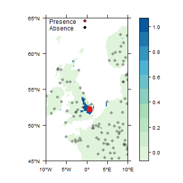

This is a nice way to debug your function and ensure you are getting the results you expect.

Once you are happy that your function is working as you expect it to you can build your code into a module using the `BuildModule` function in `zoon`. This script adds in metadata including the type of module, authors’ names, a brief description and documentation for the arguments it accepts (though this one doesn’t accept any arguments). Once `BuildModule` has created your module it will run it through checks to make sure has the required features, outputs data in the correct format, etc. Checking can be turned off by setting the argument `check = FALSE`.

```r
# Let's build our module

BuildModule(Lorem_ipsum_UK,
            type = 'occurrence',
            title = 'A dataset of Lorem ipsum occurrences',
            description = paste0('The module retrieves a dataset of',
                                 'Lorem ipsum records from figshare. This dataset contains',
                                 'precence only data and was collected between 1990 and',
                                 '2000 by members of to Lorem ipsum appreciation society'),
            details = 'This dataset is fake, Lorem ipsum does not exist',
            version = 0.1,
            author = 'A.B. Ceidi',
            email = 'ABCD@anemail.com',
            dataType = 'presence-only')
```

```
## Starting checks...
```

```
## done
```

```
## [1] "Lorem_ipsum_UK"
```

This function is fairly self explanatory, however, it is worth noting the `dataType` field. This must be any of `'presence-only'`, `'presence/absence'`, `'presence/background'`, `'abundance'` or `'proportion'`. This is important so that people using your module in the future will know what it is going to output.

`BuildModule` has now written an `R` file in our working directory containing the function and metadata, so that it can be shared with others.

```r
# First we remove the function from our workspace

rm(list = 'Lorem_ipsum_UK')

# This is how you would use a module that a colleague has sent you

LoadModule(module = 'Lorem_ipsum_UK.R')

work2 <- workflow(occurrence = Lorem_ipsum_UK,
                  covariate = UKAir,
                  process = OneHundredBackground,
                  model = LogisticRegression,
                  output = PrintMap)
```

[output not shown]

Once we’re happy with the module, we will hopefully upload it to the zoon repository. The repository is currently under development. Visit [the development pages](https://zoonproject.wordpress.com/) for more information.